# Model of Almond Yield Anomaly in Response to Climate Variation

Author

Jaden Orli

Published

April 17, 2025

# I. Background

This document implements a simple model of almond yield anomaly in response to climate variables. The transfer function for this model is sourced from Lobell et al. 2006 which used data to build statistical models of tree crop yield for California that explored how climate variation (place and time) might influence yield (Lobell, Cahill, and Field 2006). The particular equation, shown below, used is from Table 2 listed under almonds for the crop type.

$$Y = -0.015 \cdot T_{n2} - 0.0046 \cdot T_{n2}^2 - 0.07 \cdot P_{1} + 0.0043 \cdot P_{1}^2 + 0.28$$

In this equation, $T_{n2}$ represents the monthly mean minimum temperature for the second month of the year (February). Similarly, $P_{1}$ refers to the total monthly precipitation for the first month of the year (January). Using this transfer function, we developed a model to calculate the maximum yield anomaly, mean yield anomaly, and minimum yield anomaly for almonds from the years 1988 to 2010.

# II. Set Up

## a) Load Libraries

First, clear the environment and load the necessary libraries.

```r
#this clears out the environment
rm(list = ls())

#load the necessary libraries
library(readr)
library(here)
library(tidyverse)
library(kableExtra)
library(htmltools)
```

## b) Read Data

Then we will read in the climate data text file as a dataframe.

```r
#read in the climate data as a dataframe
climate_data <- read_delim(here("Data", "clim.txt"))
```

## c) Load Functions

Now we can load the R file which contains the almond_yield function.

```r
#load in the almond_yield function
source(here("R", "almond_yield.R"))

#view the format of the function
almond_yield
```

```
function (climate_df, tmin_month, precip_month)
{
    climate_month <- climate_df %>% group_by(month, year) %>%
        summarise(tmin_mean = mean(tmin_c), precip_sum = sum(precip),
            .groups = "drop")
    tmin_month_df <- climate_month %>% filter(month == tmin_month) %>%
        select(year, tmin_mean)
    precip_month_df <- climate_month %>% filter(month == precip_month) %>%
        select(year, precip_sum)
    climate_input <- inner_join(tmin_month_df, precip_month_df,
        by = "year")
    almond_yield_func <- function(tmin, precip) {
        yield <- -0.015 * tmin - 0.0046 * (tmin)^2 - 0.07 * precip +
            0.0043 * (precip)^2 + 0.28
        return(yield)
    }
    climate_yield <- climate_input %>% mutate(yield_anomaly = almond_yield_func(tmin_mean,
        precip_sum)) %>% summarise(mean_yield = mean(yield_anomaly),
        max_yield = max(yield_anomaly), min_yield = min(yield_anomaly))
    return(climate_yield)
}
```

# III. Almond Yield Anomaly

After loading all the necessary libraries, data, and functions we can use the almond_yield function that we developed to analyze the climate_data.

## a) Conceptual Model

To help understand the almond_yield function, we developed a conceptual model to explain the processes that take place within this function. The schematic for the almond yield function is outlined below:

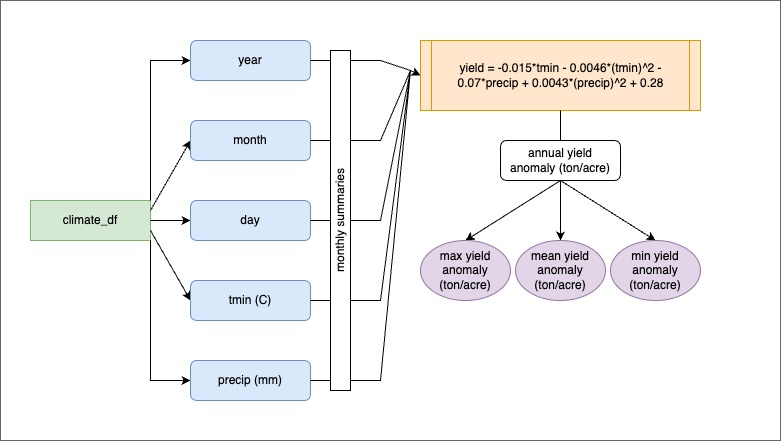

## b) Calculate Anomaly

Finally, we can use the almond_yield model to calculate the maximum, mean, and minimum yield anomalies (ton/acre) from the years 1988 to 2010.

```r
#use the almond_yield function to calculate the anomalies summary
almond_summary <- almond_yield(climate_df = climate_data, #use the climate_data as the input df
                               tmin_month = 2, #the month Lobell et al 2006 use is 2 (Feb)
                               precip_month = 1) #the month Lobell et al 2006 use is 1 (Jan)
```

And view the final outputs in a kable:

```r
#save the almond_summary as a kable
almond_kable <- kable(almond_summary,
  col.names = c("Mean Yield", "Maximum Yield", "Minimum Yield"),
  caption = htmltools::tags$div(style = "text-align: center; font-size: 1rem;",
                                    htmltools::tags$strong("Summary of Almond Yield Anomalies"),
                                    htmltools::tags$br(),
                                    htmltools::tags$span(style = "font-size: 0.9rem;", "1988–2010")),
  escape = FALSE) %>%
  kable_styling(full_width = FALSE, font_size = "0.8rem", position = "center") %>%
  row_spec(0, bold = TRUE, background = "rgba(174, 209, 200, 0.4)") %>%
  row_spec(1:nrow(almond_summary), align = "center") %>%
  kable_classic(html_font = "Times New Roman")

#view the kable
almond_kable
```

**Summary of Almond Yield Anomalies** 1988–2010

| Mean Yield | Maximum Yield | Minimum Yield |
| --- | --- | --- |
| 181.4453 | 1919.981 | -0.3552237 |

# IV. References

Lobell, David B., Kelly N. Cahill, and Christopher B. Field. 2006. “Climate Variability and Crop Production in California.” https://doi.org/10.1016/j.agee.2005.11.001.